# Homework 3

Wenxiao Yang

9/20/2021

### Part II: Homework Questions – to be submitted

1. Derive a formula relating $R^2$ and the $F$ -test for the regression. You can find the formula in the lecture slides. Here you need to derive it

$$F=\frac{(RSS_{0}-RSS_{\alpha})/q}{RSS_{\alpha}/(n-p)}=\frac{(\frac{RSS_{0}}{TSS}-\frac{RSS_{\alpha}}{TSS})/q}{\frac{RSS_{\alpha}}{TSS}/(n-p)}=\frac{((1-R_R^2)-(1-R_F^2))/(df_F-df_R)}{(1-R_F^2)/df_F}=\frac{(R_F^2-R_R^2)/(df_R-df_F)}{(1-R_F^2)/df_F}$$

2. The `whitewines.csv` data set contains information related to white variants of the Portuguese “Vinho Verde” wine. Specifically, we have recorded the following information: (a) `fixed acidity`, (b) `volatile acidity`, (c) `citric acid` , (d) `residual sugar`, (e) `chlorides` , (f) `free sulfur dioxide`, (g) `total sulfur dioxide`, (h) `density`, (i) `pH`, (j) `sulphates`, (k) `alcohol`, (l) `quality` (score between 0 and 10)

   In this homework, our goal is to explain the relationship between `alcohol level` (dependent variable) and `residual sugar`, `pH`, `density` and `fixed acidity`.
   1. Fit a regression model to the data for the four predictor variables mentioned above. State the estimated regression function.

      ```r
      whitewines.data<-read.csv("whitewines.csv",sep=";",header = TRUE)
      whitewines.reg=whitewines.data[,c(-2,-3,-5,-6,-7,-10,-12)]
      whitewines.mlr=lm(alcohol~residual.sugar+pH+density+fixed.acidity,data=whitewines.reg)
      summary(whitewines.mlr)
      ```

      ```
      ##
      ## Call:
      ## lm(formula = alcohol ~ residual.sugar + pH + density + fixed.acidity,
      ##     data = whitewines.reg)
      ##
      ## Residuals:
      ##     Min      1Q  Median      3Q     Max
      ## -3.3867 -0.2735 -0.0334  0.2200 16.9366
      ##
      ## Coefficients:
      ##                  Estimate Std. Error t value Pr(>|t|)
      ## (Intercept)     6.790e+02  4.540e+00  149.56   <2e-16 ***
      ## residual.sugar  2.367e-01  2.702e-03   87.58   <2e-16 ***
      ## pH              2.535e+00  5.281e-02   48.01   <2e-16 ***
      ## density        -6.858e+02  4.664e+00 -147.05   <2e-16 ***
      ## fixed.acidity   5.352e-01  9.858e-03   54.30   <2e-16 ***
      ## ---
      ## Signif. codes:  0 '***' 0.001 '**' 0.01 '*' 0.05 '.' 0.1 ' ' 1
      ##
      ## Residual standard error: 0.4702 on 4893 degrees of freedom
      ## Multiple R-squared:  0.8542, Adjusted R-squared:  0.854
      ## F-statistic:  7164 on 4 and 4893 DF,  p-value: < 2.2e-16
      ```

      ```r
      summary(whitewines.mlr)$coefficient
      ```

      ```
      ##                    Estimate  Std. Error    t value Pr(>|t|)
      ## (Intercept)     678.9634114 4.539785126  149.55849        0
      ## residual.sugar    0.2366782 0.002702379   87.58141        0
      ## pH                2.5354458 0.052808512   48.01207        0
      ## density        -685.8105090 4.663736406 -147.05173        0
      ## fixed.acidity     0.5352304 0.009857851   54.29484        0
      ```

      $$\widehat{\text{alcohol level}}=678.9634114+0.2366782\text{ residual sugar}+2.5354458\text{ pH}-685.8105090\text{ density}+0.5352304\text{ fixed acidity}$$
   2. Prepare partial scatter plots for all 5 variables under consideration. What do you observe?

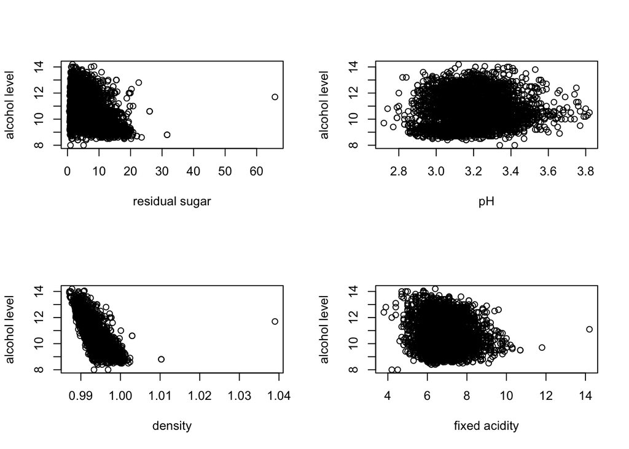

      ```r
      par (mfrow=c (2 ,2))
      plot(whitewines.reg$residual.sugar, whitewines.reg$alcohol, xlab ="residual sugar", ylab = "alcohol level" )
      plot(whitewines.reg$pH, whitewines.reg$alcohol, xlab ="pH", ylab = "alcohol level" )
      plot(whitewines.reg$density, whitewines.reg$alcohol, xlab ="density", ylab = "alcohol level" )
      plot(whitewines.reg$fixed.acidity, whitewines.reg$alcohol, xlab ="fixed acidity", ylab = "alcohol level" )
      ```

      ```r
      cor(whitewines.reg)
      ```

      ```
      ##                fixed.acidity residual.sugar     density          pH    alcohol
      ## fixed.acidity      1.0000000      0.0890207  0.26533101 -0.42585829 -0.1208811
      ## residual.sugar     0.0890207      1.0000000  0.83896645 -0.19413345 -0.4506312
      ## density            0.2653310      0.8389665  1.00000000 -0.09359149 -0.7801376
      ## pH                -0.4258583     -0.1941335 -0.09359149  1.00000000  0.1214321
      ## alcohol           -0.1208811     -0.4506312 -0.78013762  0.12143210  1.0000000
      ```

      The covariance of density and alcohol level is low(close to -1), which means they are strongly negative related to each other. The covariance of density and residual sugar is high(close to 1), which means they are strongly positive related to each other.
   4. Calculate the coefficient of multiple determination $R^2$. Interpret your results.

      ```r
      summary(whitewines.mlr)$r.square
      ```

      ```
      ## [1] 0.8541622
      ```

      $$R^2=0.8541622$$
      Which means $85.41622\%$ of total variance can be explained by the 4 variables.
   5. Test whether there is a linear regression relation, using $\alpha=0.05$. State the alternatives, decision rule, and conclusion. What does your test *imply* about $\beta_1$, $\beta_2$, $\beta_3$ and $\beta_4$?
      $$\left\{\begin{array}{l}
      H_{0}: \beta_{1}=\beta_2=\beta_3=\beta_4=0\ &(\text{null})\\
      H_{\alpha}:\text{For some }j=1,2,3,4:\ \beta_{j} \neq 0\ &(\text{alternative})
      \end{array}\right.$$

      ```r
      summary(whitewines.mlr)$fstat
      ```

      ```
      ##    value    numdf    dendf
      ## 7164.496    4.000 4893.000
      ```

      the f-statistics is 7164.496 with ${df}_1=4$, ${df}_2=4893$, then we need to compute the $p-$value. If the $p-$value$<0.05$, reject null hypothesis.

      ```r
      1-pf(summary(whitewines.mlr)$fstat[1],4,4893)
      ```

      ```
      ## value
      ##     0
      ```

      The $p-$value is $0<0.05$, so we reject the null hypothesis. Which means there is a linear regression relation. This also imply there is at least one $\beta_j\neq0,\ j=1,2,3,4$.
   6. Test whether $X_3$ can be dropped from the regression model given that $X_1$, $X_2$ are retained. Use level of significance 0.025. State the alternatives, decision rule and conclusion.
      $$\left\{\begin{array}{l}
      H_{0}: \beta_3=0\ &(\text{null})\\
      H_{\alpha}:\beta_3\neq0\ &(\text{alternative})
      \end{array}\right.$$

      ```r
      whitewines.mlr.full=lm(alcohol~residual.sugar+pH+density,data=whitewines.reg)
      whitewines.mlr.reduced1=lm(alcohol~residual.sugar+pH,data=whitewines.reg)
      anova (whitewines.mlr.reduced1, whitewines.mlr.full)
      ```

      ```
      ## Analysis of Variance Table
      ##
      ## Model 1: alcohol ~ residual.sugar + pH
      ## Model 2: alcohol ~ residual.sugar + pH + density
      ##   Res.Df    RSS Df Sum of Sq     F    Pr(>F)
      ## 1   4895 5901.3
      ## 2   4894 1733.2  1    4168.1 11770 < 2.2e-16 ***
      ## ---
      ## Signif. codes:  0 '***' 0.001 '**' 0.01 '*' 0.05 '.' 0.1 ' ' 1
      ```

      f-statistics is 11770. Then we need to compute $p-$value. If the $p-$value$<0.025$, we can reject the null hypothesis.

      ```r
      1-pf(11770,1,4894)
      ```

      ```
      ## [1] 0
      ```

      ```r
      whitewines.mlr.reduced2=lm(alcohol~density,data=whitewines.reg)
      anova (whitewines.mlr.reduced2, whitewines.mlr.full)
      ```

      ```
      ## Analysis of Variance Table
      ##
      ## Model 1: alcohol ~ density
      ## Model 2: alcohol ~ residual.sugar + pH + density
      ##   Res.Df    RSS Df Sum of Sq    F    Pr(>F)
      ## 1   4896 2902.6
      ## 2   4894 1733.2  2    1169.4 1651 < 2.2e-16 ***
      ## ---
      ## Signif. codes:  0 '***' 0.001 '**' 0.01 '*' 0.05 '.' 0.1 ' ' 1
      ```

      f-statistics is 1651. Then we need to compute $p-$value. If the $p-$value$<0.025$, we can reject the null hypothesis.

      ```r
      1-pf(1651,2,4894)
      ```

      ```
      ## [1] 0
      ```